# Importing necessary modules

```python
import numpy as np                #General-purpose array-processing package
import pandas as pd               #Package for analysing data
import seaborn as sns             #Library of statistical functions
import matplotlib.pyplot as plt   #For plotting graphs
%matplotlib inline
```

# Data warehouse

## Loading the data

```python
data = pd.read_csv('basketball.csv') #loading data with csv file format
```

```python
data.head(22)                          #visualizing top rows of the dataset
```

|  | Team | Tournament | Score | PlayedGames | WonGames | DrawnGames | LostGames | BasketScored | BasketGiven | TournamentChampion | Runner-up | TeamLaunch | HighestPositionHeld |
| --- | --- | --- | --- | --- | --- | --- | --- | --- | --- | --- | --- | --- | --- |
| 0 | Team 1 | 86 | 4385 | 2762 | 1647 | 552 | 563 | 5947 | 3140 | 33 | 23 | 1929 | 1 |
| 1 | Team 2 | 86 | 4262 | 2762 | 1581 | 573 | 608 | 5900 | 3114 | 25 | 25 | 1929 | 1 |
| 2 | Team 3 | 80 | 3442 | 2614 | 1241 | 598 | 775 | 4534 | 3309 | 10 | 8 | 1929 | 1 |
| 3 | Team 4 | 82 | 3386 | 2664 | 1187 | 616 | 861 | 4398 | 3469 | 6 | 6 | 1931to32 | 1 |
| 4 | Team 5 | 86 | 3368 | 2762 | 1209 | 633 | 920 | 4631 | 3700 | 8 | 7 | 1929 | 1 |
| 5 | Team 6 | 73 | 2819 | 2408 | 990 | 531 | 887 | 3680 | 3373 | 1 | 4 | 1934-35 | 1 |
| 6 | Team 7 | 82 | 2792 | 2626 | 948 | 608 | 1070 | 3609 | 3889 | - | - | 1929 | 3 |
| 7 | Team 8 | 70 | 2573 | 2302 | 864 | 577 | 861 | 3228 | 3230 | 2 | 3 | 1929 | 1 |
| 8 | Team 9 | 58 | 2109 | 1986 | 698 | 522 | 766 | 2683 | 2847 | - | 1 | 1939-40 | 2 |
| 9 | Team 10 | 51 | 1884 | 1728 | 606 | 440 | 682 | 2159 | 2492 | 1 | - | 1932-33 | 1 |
| 10 | Team 11 | 45 | 1814 | 1530 | 563 | 392 | 575 | 2052 | 2188 | 1 | 5 | 1941to42 | 1 |
| 11 | Team 12 | 51 | 1789 | 1698 | 586 | 389 | 723 | 2278 | 2624 | - | - | 1939-40 | 4 |
| 12 | Team 13 | 42 | 1471 | 1466 | 463 | 384 | 619 | 1767 | 2180 | - | - | 1948-49 | 4 |
| 13 | Team 14 | 44 | 1416 | 1428 | 453 | 336 | 639 | 1843 | 2368 | - | 1 | 1929 | 2 |
| 14 | Team 15 | 43 | 1389 | 1458 | 471 | 358 | 629 | 1753 | 2152 | - | 1 | 1944_45 | 2 |
| 15 | Team 16 | 37 | 1351 | 1318 | 426 | 327 | 565 | 1500 | 1834 | - | - | 1935-36 | 4 |
| 16 | Team 17 | 36 | 1314 | 1255 | 390 | 330 | 535 | 1421 | 1763 | - | - | 1949_50 | 4 |
| 17 | Team 18 | 38 | 1174 | 1192 | 408 | 292 | 492 | 1642 | 1951 | - | - | 1933to34 | 3 |
| 18 | Team 19 | 27 | 1148 | 988 | 333 | 256 | 399 | 1182 | 1371 | - | - | 1960-61 | 3 |
| 19 | Team 20 | 33 | 1020 | 1096 | 367 | 242 | 487 | 1347 | 1746 | - | 1 | 1951-52 | 2 |
| 20 | Team 21 | 17 | 970 | 646 | 266 | 172 | 208 | 892 | 789 | - | 1 | 1998-99 | 2 |
| 21 | Team 22 | 23 | 667 | 742 | 218 | 175 | 349 | 819 | 1157 | - | - | 1941-42 | 6 |

```python
data.tail(5)                           #Visualizing bottom rows of the dataset
```

|  | Team | Tournament | Score | PlayedGames | WonGames | DrawnGames | LostGames | BasketScored | BasketGiven | TournamentChampion | Runner-up | TeamLaunch | HighestPositionHeld |
| --- | --- | --- | --- | --- | --- | --- | --- | --- | --- | --- | --- | --- | --- |
| 56 | Team 57 | 1 | 34 | 38 | 8 | 10 | 20 | 38 | 66 | - | - | 2009-10 | 20 |
| 57 | Team 58 | 1 | 22 | 30 | 7 | 8 | 15 | 37 | 57 | - | - | 1956-57 | 16 |
| 58 | Team 59 | 1 | 19 | 30 | 7 | 5 | 18 | 51 | 85 | - | - | 1951~52 | 16 |
| 59 | Team 60 | 1 | 14 | 30 | 5 | 4 | 21 | 34 | 65 | - | - | 1955-56 | 15 |
| 60 | Team 61 | 1 | - | - | - | - | - | - | - | - | - | 2017~18 | 9 |

## inference:

there are unwanted symbols making data unfit to use

# Data exploration and preprocessing

```python
Data = data.replace('-',np.NaN)           #Replacing "-" value with Nan in the entire dataset
```

```python
Data.info()                              #Printing a concise summary of a DataFrame
```

```
<class 'pandas.core.frame.DataFrame'>
RangeIndex: 61 entries, 0 to 60
Data columns (total 13 columns):
Team                   61 non-null object
Tournament             61 non-null int64
Score                  60 non-null object
PlayedGames            60 non-null object
WonGames               60 non-null object
DrawnGames             60 non-null object
LostGames              60 non-null object
BasketScored           60 non-null object
BasketGiven            60 non-null object
TournamentChampion     9 non-null object
Runner-up              13 non-null object
TeamLaunch             61 non-null object
HighestPositionHeld    61 non-null int64
dtypes: int64(2), object(11)
memory usage: 6.3+ KB
```

```python
Data = Data.rename(columns={'Runner-up':'Runner_up'})
```

```python
Data.isnull().sum()                        #detecting missing values and getting a sum from each colum
```

```
Team                    0
Tournament              0
Score                   1
PlayedGames             1
WonGames                1
DrawnGames              1
LostGames               1
BasketScored            1
BasketGiven             1
TournamentChampion     52
Runner_up              48
TeamLaunch              0
HighestPositionHeld     0
dtype: int64
```

```python
Data.Runner_up = Data.Runner_up.fillna(0)  #Filling NA/NaN values using the specified method.
```

```python
Data.TournamentChampion = Data.TournamentChampion.fillna(0) #Filling NA/NaN values using the specified method.
```

# data visualisation

```python
Data = Data.drop(Data.index[-1])
```

### changing dtypes from object to integer to perform operation

```python
Data1 = Data.loc[:,['Tournament','Score','PlayedGames','WonGames','DrawnGames','LostGames','BasketScored','BasketGiven','TournamentChampion','Runner_up','HighestPositionHeld']].apply(pd.to_numeric)
```

```python
Data2 = Data.loc[:,['Team','TeamLaunch']]
```

```python
Final_data = pd.concat([Data2,Data1], axis=1) #total data with interger and object Dtypes
```

```python
Final_data.info()
```

```
<class 'pandas.core.frame.DataFrame'>
Int64Index: 60 entries, 0 to 59
Data columns (total 13 columns):
Team                   60 non-null object
TeamLaunch             60 non-null object
Tournament             60 non-null int64
Score                  60 non-null int64
PlayedGames            60 non-null int64
WonGames               60 non-null int64
DrawnGames             60 non-null int64
LostGames              60 non-null int64
BasketScored           60 non-null int64
BasketGiven            60 non-null int64
TournamentChampion     60 non-null int64
Runner_up              60 non-null int64
HighestPositionHeld    60 non-null int64
dtypes: int64(11), object(2)
memory usage: 6.6+ KB
```

```python
Final_data.corr()                            #Computing pairwise correlation of columns
```

|  | Tournament | Score | PlayedGames | WonGames | DrawnGames | LostGames | BasketScored | BasketGiven | TournamentChampion | Runner_up | HighestPositionHeld |
| --- | --- | --- | --- | --- | --- | --- | --- | --- | --- | --- | --- |
| Tournament | 1.000000 | 0.981258 | 0.998683 | 0.971749 | 0.989295 | 0.949350 | 0.974867 | 0.987781 | 0.589304 | 0.645924 | -0.708002 |
| Score | 0.981258 | 1.000000 | 0.979687 | 0.997232 | 0.958090 | 0.878780 | 0.996634 | 0.943801 | 0.715014 | 0.764819 | -0.669215 |
| PlayedGames | 0.998683 | 0.979687 | 1.000000 | 0.967486 | 0.993972 | 0.955925 | 0.969970 | 0.990020 | 0.575072 | 0.633101 | -0.711065 |
| WonGames | 0.971749 | 0.997232 | 0.967486 | 1.000000 | 0.939416 | 0.851436 | 0.999312 | 0.925745 | 0.752904 | 0.797849 | -0.647819 |
| DrawnGames | 0.989295 | 0.958090 | 0.993972 | 0.939416 | 1.000000 | 0.972786 | 0.942234 | 0.992479 | 0.503378 | 0.566021 | -0.720248 |
| LostGames | 0.949350 | 0.878780 | 0.955925 | 0.851436 | 0.972786 | 1.000000 | 0.857843 | 0.985041 | 0.324025 | 0.391645 | -0.726172 |
| BasketScored | 0.974867 | 0.996634 | 0.969970 | 0.999312 | 0.942234 | 0.857843 | 1.000000 | 0.931079 | 0.743847 | 0.791041 | -0.648672 |
| BasketGiven | 0.987781 | 0.943801 | 0.990020 | 0.925745 | 0.992479 | 0.985041 | 0.931079 | 1.000000 | 0.471618 | 0.533448 | -0.727323 |
| TournamentChampion | 0.589304 | 0.715014 | 0.575072 | 0.752904 | 0.503378 | 0.324025 | 0.743847 | 0.471618 | 1.000000 | 0.971533 | -0.304307 |
| Runner_up | 0.645924 | 0.764819 | 0.633101 | 0.797849 | 0.566021 | 0.391645 | 0.791041 | 0.533448 | 0.971533 | 1.000000 | -0.359191 |
| HighestPositionHeld | -0.708002 | -0.669215 | -0.711065 | -0.647819 | -0.720248 | -0.726172 | -0.648672 | -0.727323 | -0.304307 | -0.359191 | 1.000000 |

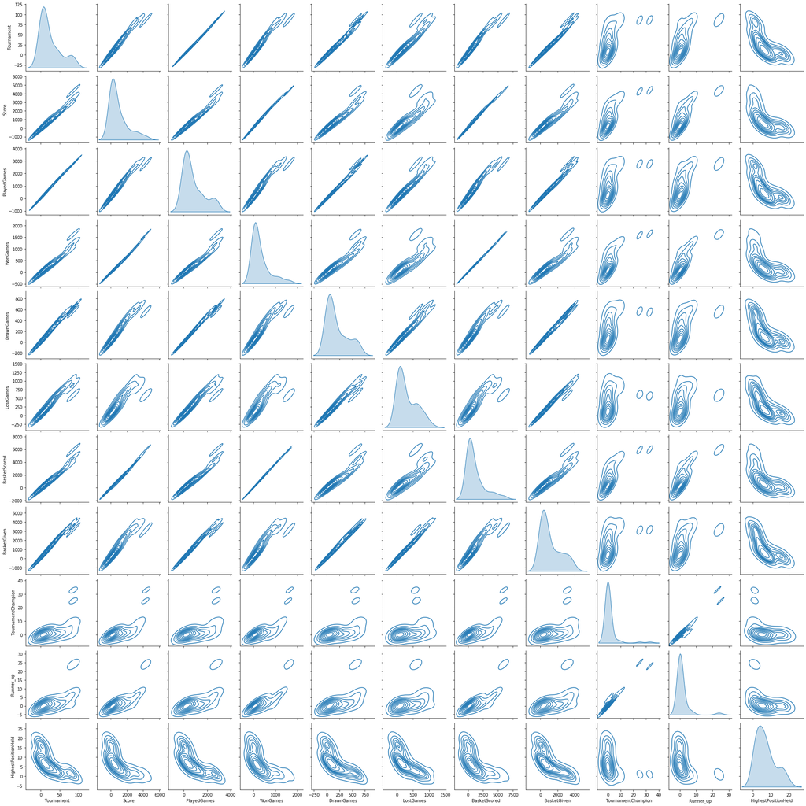

```python
sns.pairplot(Final_data,kind='kde')            #plot of pairwise relationships of columns
plt.show()
```

# Heatmap for correlation

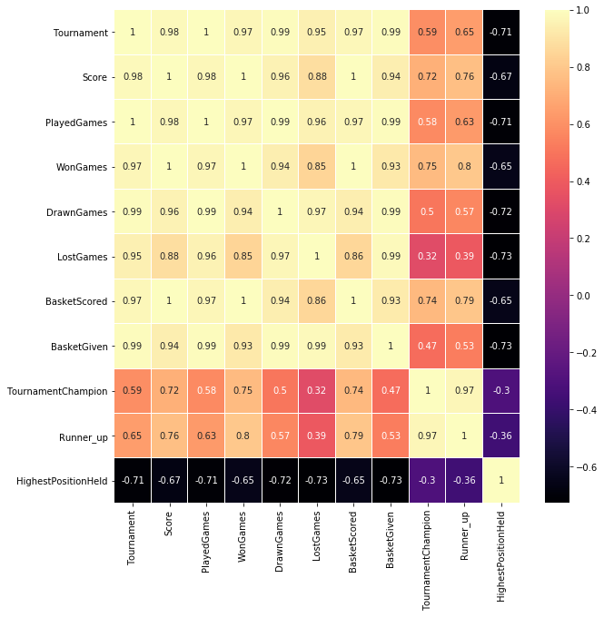

```python
fig,ax = plt.subplots(figsize=(10,10))
ax=sns.heatmap(Final_data.corr(),annot=True,linewidths=0.01,fmt='.2g',cmap="magma")  #Plot rectangular data as a color-encoded matrix
bottom,top = ax.get_ylim()
ax.set_ylim(bottom + 0.5, top - 0.5)
plt.show()
```

A high correlation was found between Basket-Scored and Score, Basket-Scored and Won games with a correlation of 1. High correlation was also found between Runner-up and TournamentChampion

## Statistical analysis

### Adding new features

```python
Final_data['BasketRatio'] = (Final_data['BasketScored']/Final_data['BasketGiven']) #adding New columns using existing DataFrame to perform meaning statistical analysis
Final_data['WinRatio']    = (Final_data["WonGames"]/Final_data['PlayedGames'])
Final_data['LossRatio']   = (Final_data["LostGames"]/Final_data['PlayedGames'])
Final_data['Win_loss']    = (Final_data["WonGames"]/Final_data['LostGames'])
Final_data['DrawnRatio']  = (Final_data["DrawnGames"]/Final_data['PlayedGames'])
Final_data.head(5)
```

|  | Team | TeamLaunch | Tournament | Score | PlayedGames | WonGames | DrawnGames | LostGames | BasketScored | BasketGiven | TournamentChampion | Runner_up | HighestPositionHeld | BasketRatio | WinRatio | LossRatio | Win_loss | DrawnRatio |
| --- | --- | --- | --- | --- | --- | --- | --- | --- | --- | --- | --- | --- | --- | --- | --- | --- | --- | --- |
| 0 | Team 1 | 1929 | 86 | 4385 | 2762 | 1647 | 552 | 563 | 5947 | 3140 | 33 | 23 | 1 | 1.893949 | 0.596307 | 0.203838 | 2.925400 | 0.199855 |
| 1 | Team 2 | 1929 | 86 | 4262 | 2762 | 1581 | 573 | 608 | 5900 | 3114 | 25 | 25 | 1 | 1.894669 | 0.572411 | 0.220130 | 2.600329 | 0.207458 |
| 2 | Team 3 | 1929 | 80 | 3442 | 2614 | 1241 | 598 | 775 | 4534 | 3309 | 10 | 8 | 1 | 1.370202 | 0.474751 | 0.296480 | 1.601290 | 0.228768 |
| 3 | Team 4 | 1931to32 | 82 | 3386 | 2664 | 1187 | 616 | 861 | 4398 | 3469 | 6 | 6 | 1 | 1.267801 | 0.445571 | 0.323198 | 1.378630 | 0.231231 |
| 4 | Team 5 | 1929 | 86 | 3368 | 2762 | 1209 | 633 | 920 | 4631 | 3700 | 8 | 7 | 1 | 1.251622 | 0.437726 | 0.333092 | 1.314130 | 0.229182 |

# Plot 1

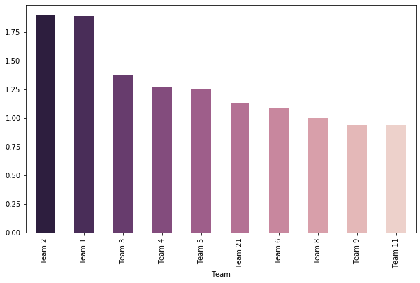

```python
top_Teams_basket = Final_data.groupby(['Team'])['BasketRatio'].sum().reset_index().sort_values('BasketRatio',ascending=False)
top_Teams_basket.head(10).plot(x="Team",y="BasketRatio",kind='bar',legend=None,figsize=(10,6),color=sns.cubehelix_palette(10,reverse=True))
```

# Inference

From the above plot we can infer the top 10 teams which have high basket scored to basked Given ratio making it a very good criteria for a organisation to pick them(higher the number the better a team performed). They are mostly team1 to team 10 but an exception with team 21 which ranks at 6th from a total of 10 teams.

# Plot 2

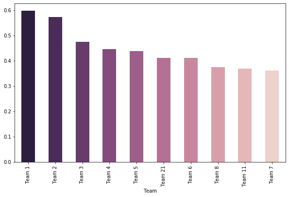

```python
top_Teams_wins = Final_data.groupby(['Team'])['WinRatio'].sum().reset_index().sort_values('WinRatio',ascending=False)
top_Teams_wins.head(10).plot(x="Team",y="WinRatio",kind='bar',legend=None,figsize=(10,6),color=sns.cubehelix_palette(10,reverse=True))
```

# Inference

This plot gives us the win ratio(number of games won/number of games played) of each team,from the ranking order we can again infer that except teams (10 and 9) the other made it to top 10 with exception being team21 performing at top 6 and team 11 at 9th.

# Plot 3

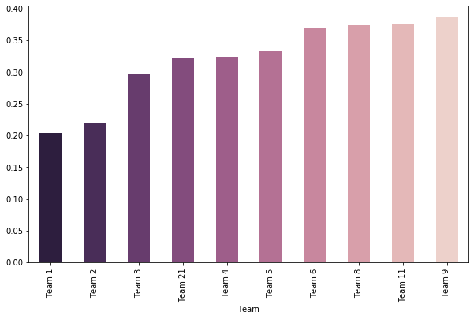

```python
top_Teams_loss = Final_data.groupby(['Team'])['LossRatio'].sum().reset_index().sort_values('LossRatio',ascending=True)
top_Teams_loss.head(10).plot(x="Team",y="LossRatio",kind='bar',legend=None,figsize=(10,6),color=sns.cubehelix_palette(10,reverse=True))
```

# inference

The above plots gives us that ratio of games lost by a team to the total number of games played by that team(So lover the better). from the ranking order we can infer that team21 has performed expectional well in this category with a rank of 4 making it a good choice for organisation to pick.

# Plot 4

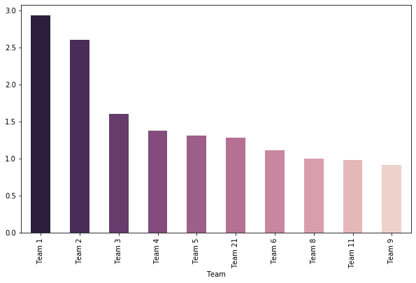

```python
top_Teams_win_loss = Final_data.groupby(['Team'])['Win_loss'].sum().reset_index().sort_values('Win_loss',ascending=False)
top_Teams_win_loss.head(10).plot(x="Team",y="Win_loss",kind='bar',legend=None,figsize=(10,6),color=sns.cubehelix_palette(10,reverse=True))
```

# Inference

This plot gives us the ration of games won to games lost of each team ranking to top10(so higher the better)

# SUMMARY

From the above four plots we can get the top 10 performing teams to pick for an organisaton ,The list being Team1, Team 2, Team 3, Team 4, Team 5, Team21, Team 6, Team 8, Team 11 and team 9, So the data just after careful preprocessing steps gives the top ten teams but after adding features(Win_Ratio,Loss_ratio,Basket_ratio and win/loss) based on the correlation matrix. Team21 can be seen to perform very well based on new addition of features making it to the top 10 best performing teams.

## Future suggestions on data collection

- 1.To perform better analysis in finding best teams, Players data of each team is also a must as we can infer a lot from individual player and how they lift the team as a whole, for example a team with high player efficiency ratings and MVP etc can perform better than a team with less PER players.
- 2.Data of the support a team has from Fans to number of wins.
- 3.Data of the coaches of a team and the number of wins/losses occured with respect to a particular coach.
- To make the data analysis more constructive an updated player data is a must